# Fitting a proliferation model with complex mixture

# Introduction

This vignette accompanies the ProliferationAnalysis package, to run semi automated proliferation models in a high throughput manner. It has options to deconvolute the effect of complex mixtures of cells where a stain negative population is present in the sample. These stain negative cells can unduly influence proliferation statistics.

IMPORTANT NOTE: This is NOT a guide to best practices to performing a proliferation experiment and assumes some basic knowledge on getting a FACS proliferation trace ready and evaluating its quality. This does NOT cover how to setup gates etc.

```r
library(ProliferationAnalysis)
data("ctv_example")
```

### Example data

The package comes bundled with some example traces.

#### Sample with no mixture (sample.a)

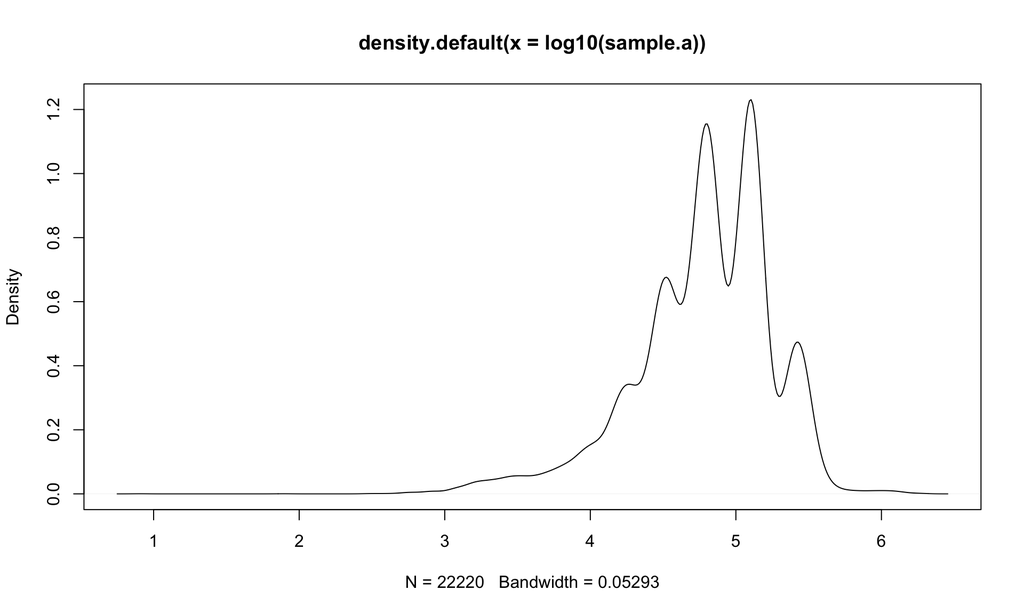

```r
sample.a <- ctv[[10]]

plot(density(log10(sample.a)),
     type="l")
```

#### Sample with high mixture (sample.b)

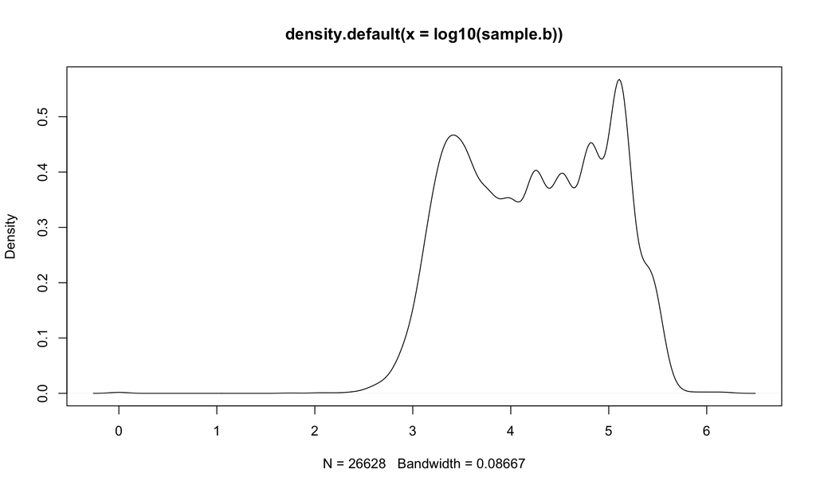

```r
sample.b <- ctv[[28]]

plot(density(log10(sample.b)),
     type="l")
```

# Fitting a proliferation model to CTV traces

The first step before we run proliferation modeling is to extract the raw per-cell CTV (other dyes are available) intensities from the .fcs files and gate on single cells *. Depending on your goals, you can then proceed in two ways.

1. If you have no mixture of cells I would recommend gating on the CTV+ population to avoid debris and CTV- cells affecting the fit. Then proceed with example 1.
2. If you have a complex cell sample where only a portion of cells have been stained, proceed with example 2.

* This package does NOT handle this part, and would refer you to the plethora of FACS analysis options available in R. I quite like CytoExploreR for gating.

## Example one

### Step 0: Choose your optimizer

The package offers two optimization schemes.

1. Non linear least squares (LS) with mode=“LS”. Here the data is first binned and smoothed, then parameters are optimized over the smoothed trace using non linear least squares. This method is quick and robust, but relies on binning and some other data processing so is technically less accurate.
2. Maximum likelihood estimation (MLE) based with mode=“MLE”. This mode is a little more proper in that it does not rely on binning or other data tricks to optimize, and takes the full data set to optimize on directly. Initial parameter estimation is still done on a binned smoothed version of the data, but optimization is not.

In practice I have found very little difference between these two when the setup is performed correctly. Some examples below of issues you may encounter.

### Step 1: Identify gen0

First, Identify the rough cutoff where the undivided generation is. This cutoff needs to be left of the mode of gen 0. I recommend putting it into the valley after the first mode. This can be set in a consistent way for your samples using a CytoExploreR gate by your negative control sample. In this case we will be setting it manually.

Note this does not directly affect the fit, and is just used to find the mode of gen0 in each sample.

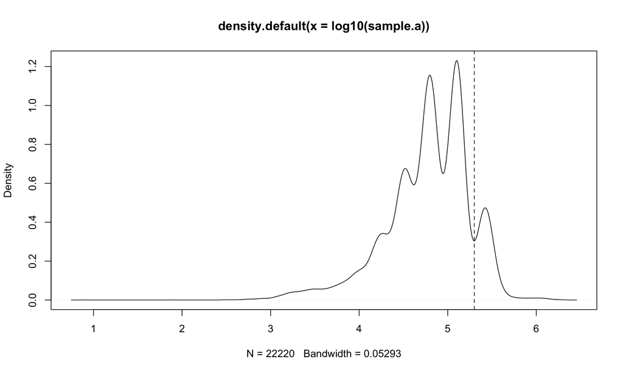

```r
gen0.cutoff <- 5.3

plot(density(log10(sample.a)), type="l")
abline(v=gen0.cutoff, lty=2)
```

### Step 2: fit peaks

In the simplest case we can run fit.peaks, which estimates peak numbers automatically. We will look later on at performing and tweaking a fit step by step.

```r
# Basic fit
fit <- fit.peaks(trace=sample.a,
                 peak.0.lower.bound=gen0.cutoff,
                 mode="LS")
```

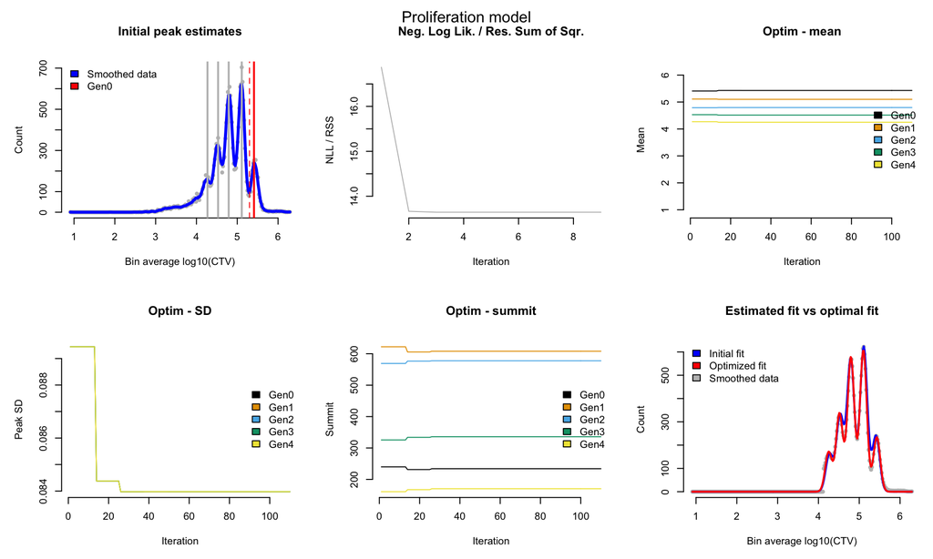

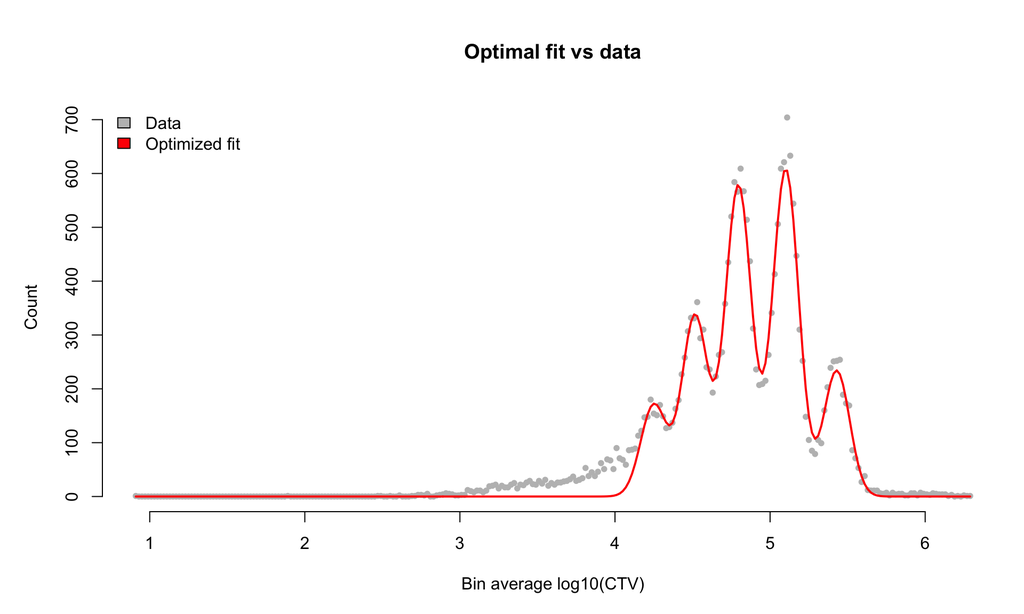

This can be useful to diagnose issues if you get weird looking fits.

The final single plot shows the original trace vs the optimized model.

### Step 3: Evaluate and diagnose issues

If we run the same example again, but now using the MLE optimization procedure we can see something is off.

```r
# Basic fit with MLE goes wrong
fit <- fit.peaks(trace=sample.a,
                 peak.0.lower.bound=gen0.cutoff,
                 mode="MLE")
```

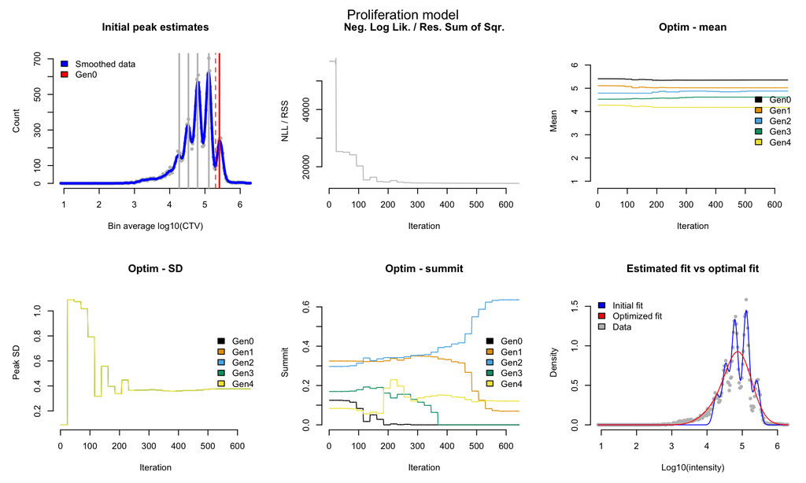

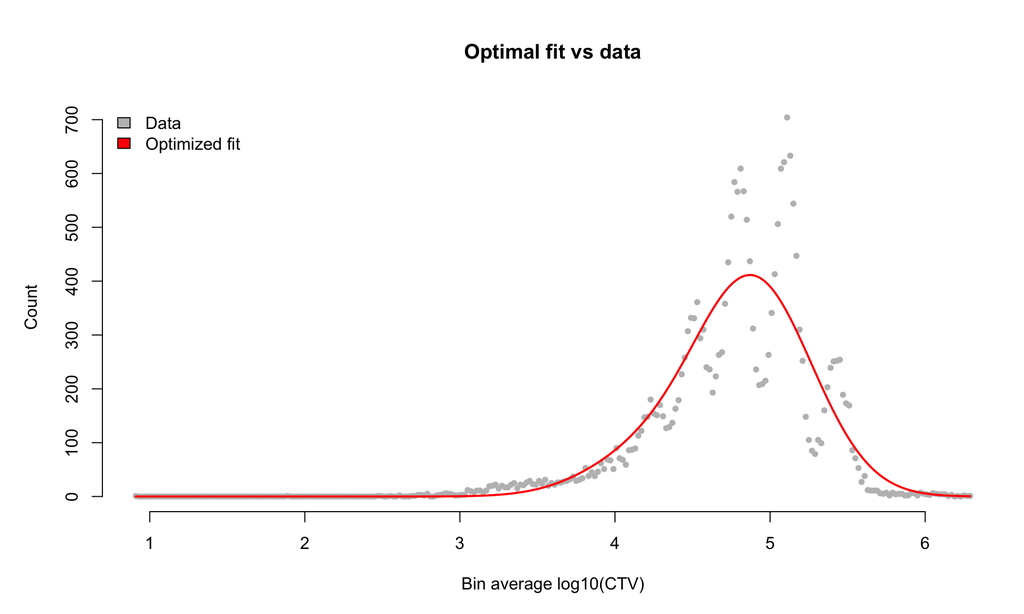

In this case the left tail in the data is causing the most optimal fit to be a single distribution that covers the tail. This is clearly wrong and has as a cause that the automated peak estimates don’t cover this tail. Note, this behavior is not limited to the MLE optimizer, it just so happens this particular combination of data sends the optimizer down this path and the way the constraints are setup in the different modes.

This can be solved in 2 ways:

#### Option 1

Fix the fit by strictly gating out the on the CTV- and CTV ++ tails. This is a simple solution but keep in mind that it might not be the most accurate. In practicethis is well within reasonable limits to do, as you would also do this in common software such as FlowJo or FCS express. This gating can easily be performed on all your samples in CytoExploreR or other FCS analysis packages.

```r
fit <- fit.peaks(trace=sample.a[log10(sample.a) > 4 & log10(sample.a) < 5.6],
                 peak.0.lower.bound=gen0.cutoff,
                 mode="MLE")
```

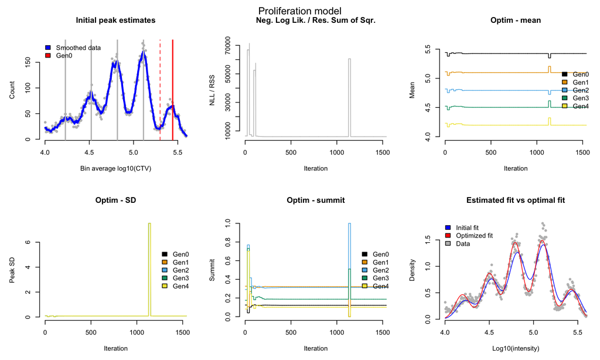

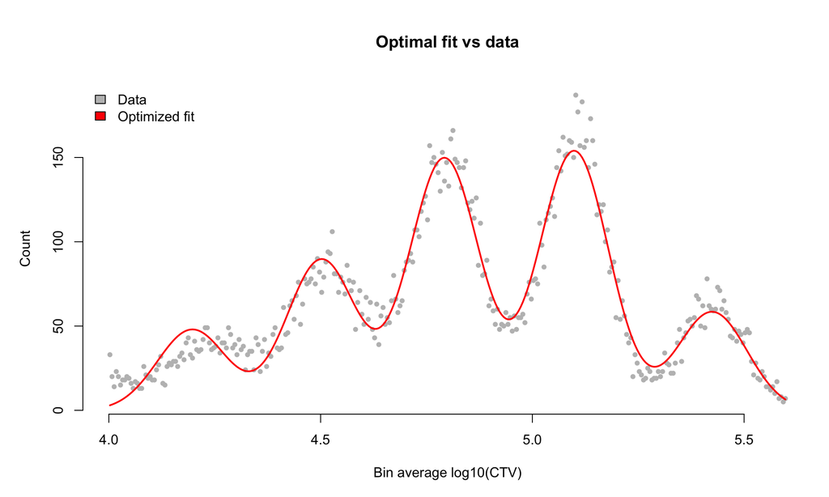

#### Option 2

Allow more peaks to be fit in the model by relaxing initial estimation thresholds. This can be achieved by tweaking peak.thresh.enrich, peak.thresh.summit and peak.max. Some amount of gating may still be needed to avoid this issue as MLE is quite sensitive to optimizing the likelihood so the tails are included.

In least squares mode this issue is avoided by trimming the left tail to zero prior to optimization for values outside the model range. This is effectively equivalent to setting a strict gate on the model range.

```r
fit <- fit.peaks(trace=sample.a[log10(sample.a) > 3 & log10(sample.a) < 5.6],
                 peak.0.lower.bound=gen0.cutoff,
                 mode="MLE",
                 peak.thresh.enrich=0,
                 peak.thresh.summit=0)
```

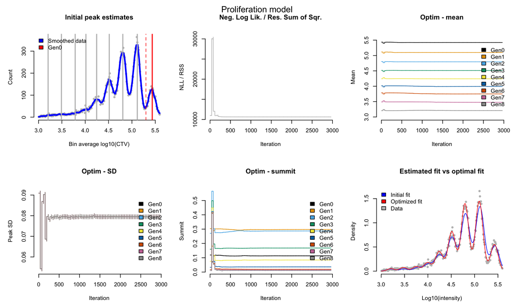

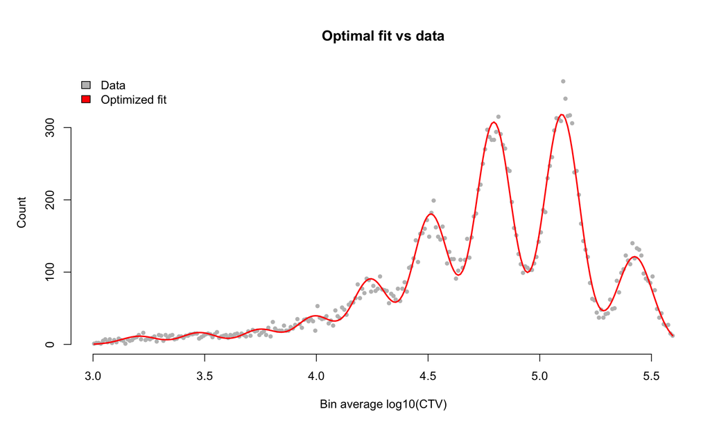

If we now run the same parameters using NLS we will see we will find a similar model.

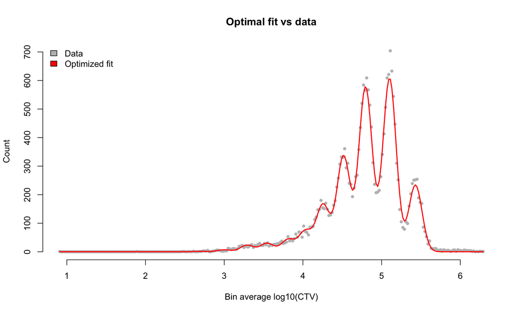

```r
fit <- fit.peaks(trace=sample.a,
                 peak.0.lower.bound=gen0.cutoff,
                 mode="LS",
                 peak.thresh.enrich=0,
                 peak.thresh.summit=0,
                 plot.optim=F)
```

We can control the trimming of the tail using the option opt.trim.left.tail In this case it makes little difference due to the way parameter constraints are setup. But this can be sample specific!

In this example, we forcibly misspecify the model to show how trimming the left tail outside of the initial estimates influences the optimizer.

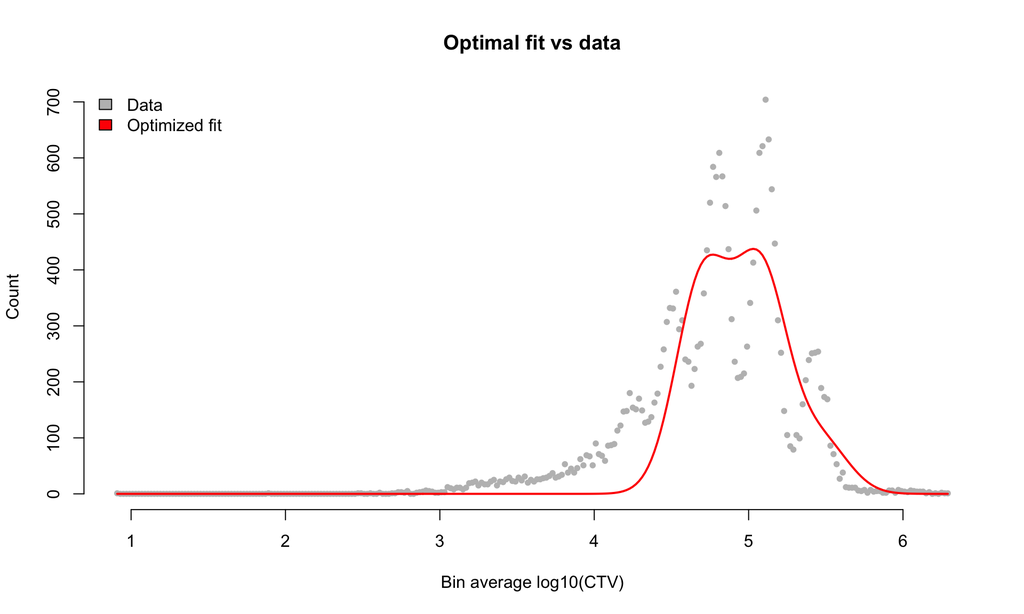

```r
par(mfrow=c(2,1))
fit <- fit.peaks(trace=sample.a,
                 peak.0.lower.bound=gen0.cutoff,
                 mode="LS",
                 peak.thresh.enrich=0,
                 peak.thresh.summit=0,
                 peak.max=2,
                 opt.trim.left.tail=F,
                 plot.optim=F)
```

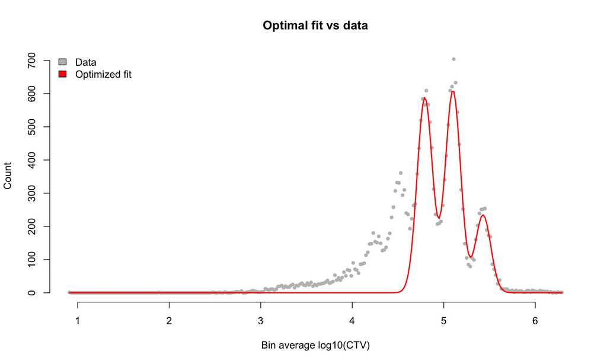

```r
fit <- fit.peaks(trace=sample.a,
                 peak.0.lower.bound=gen0.cutoff,
                 mode="LS",
                 peak.thresh.enrich=0,
                 peak.thresh.summit=0,
                 peak.max=2,
                 opt.trim.left.tail=T,
                 plot.optim=F)
```

```r
par(mfrow=c(1,1))
```